# Data 624 - Homework 3

John Kellogg

2/27/2021

## Question 2:

**The ‘plastics’ data set consists of the monthly sales (in thousands) of product A for a plastics manufacturer for five years.**

```r
plastics
```

```
##    Jan  Feb  Mar  Apr  May  Jun  Jul  Aug  Sep  Oct  Nov  Dec
## 1  742  697  776  898 1030 1107 1165 1216 1208 1131  971  783
## 2  741  700  774  932 1099 1223 1290 1349 1341 1296 1066  901
## 3  896  793  885 1055 1204 1326 1303 1436 1473 1453 1170 1023
## 4  951  861  938 1109 1274 1422 1486 1555 1604 1600 1403 1209
## 5 1030 1032 1126 1285 1468 1637 1611 1608 1528 1420 1119 1013
```

### 2a.

**Plot the time series of sales of product A. Can you identify seasonal fluctuations and/or a trend-cycle?**

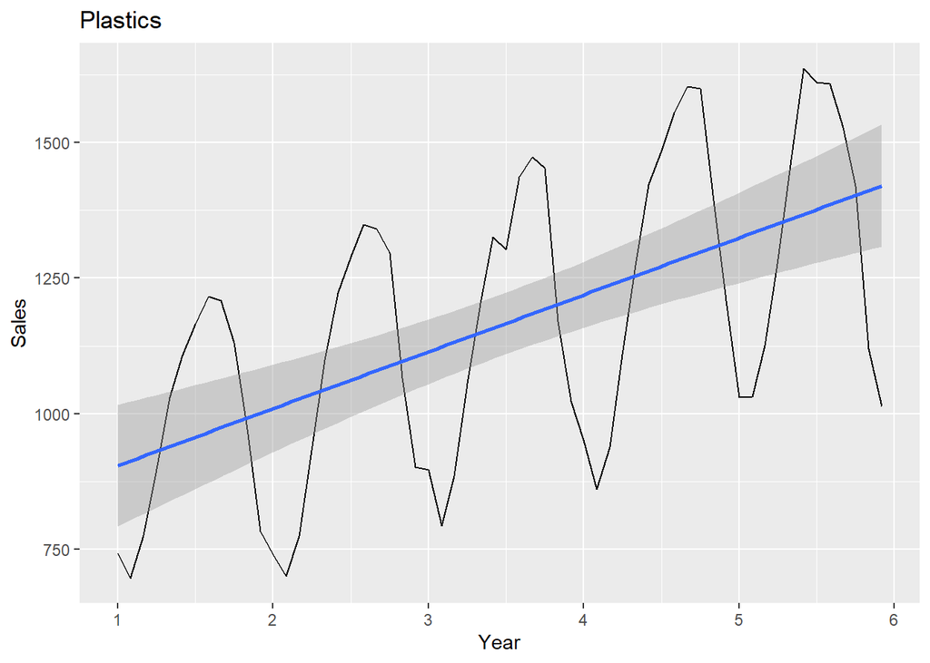

```r
autoplot(plastics)+
  labs(title = "Plastics")+
  geom_smooth(method = "lm")+
  ylab("Sales")+
  xlab("Year")
```

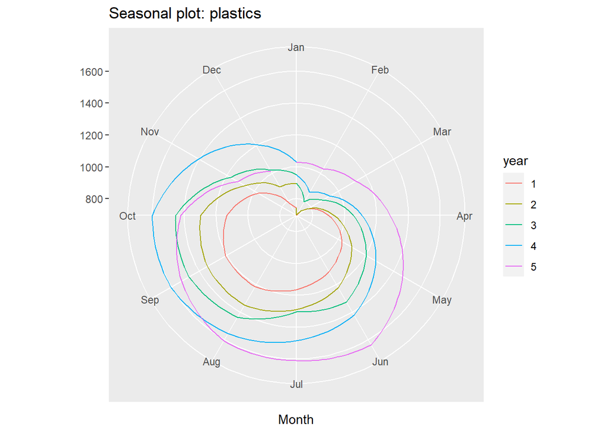

```r
ggseasonplot(plastics, polar=TRUE)
```

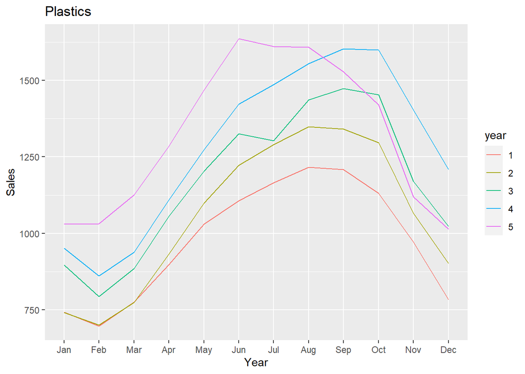

```r
ggseasonplot(plastics)+
  labs(title = "Plastics")+
  ylab("Sales")+
  xlab("Year")
```

### 2b.

**Use a classical multiplicative decomposition to calculate the trend-cycle and seasonal indices.**

```r
Q2b <- decompose(plastics, type = "multiplicative")
autoplot(Q2b)
```

[output not shown]

### 2c.

**Do the results support the graphical interpretation from part a?**

- Yes
  - The seasonal cycle seen in the graphs from question A are represented
  - The upwards trend is present

### 2d.

**Compute and plot the seasonally adjusted data.**

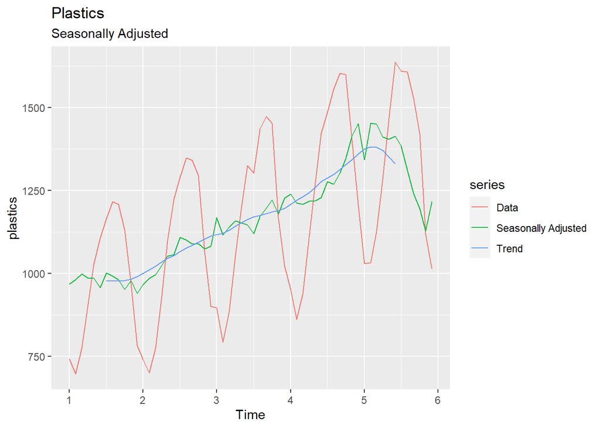

```r
autoplot(plastics, series = "Data")+
  autolayer(seasadj(Q2b), series = "Seasonally Adjusted")+
  autolayer(trendcycle(Q2b), series = "Trend")+
  labs(title = "Plastics", subtitle = "Seasonally Adjusted")
```

### 2e.

**Change one observation to be an outlier (e.g., add 500 to one observation), and recompute the seasonally adjusted data. What is the effect of the outlier?**

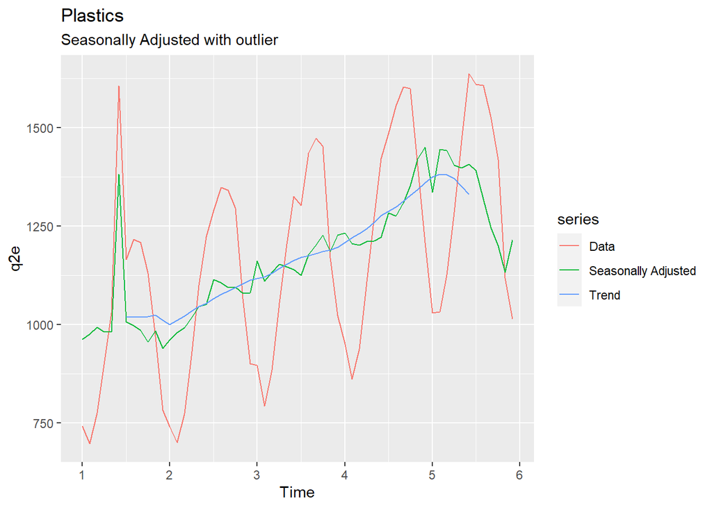

```r
#sample(1:60,1,replace = FALSE)
#Sample chose #6
q2e <- plastics
q2e[6] <- q2e[6] + 500

outlier <- q2e %>%
  decompose(type = "multiplicative")

autoplot(q2e, series = "Data")+
  autolayer(seasadj(outlier), series = "Seasonally Adjusted")+
  autolayer(trendcycle(outlier), series = "Trend")+
  labs(title = "Plastics", subtitle = "Seasonally Adjusted with outlier")
```

#### Plastics with no outlier

```r
plastics %>% decompose(type = "multiplicative")%>%
  autoplot()
```

[output not shown]

#### Plastics with outlier

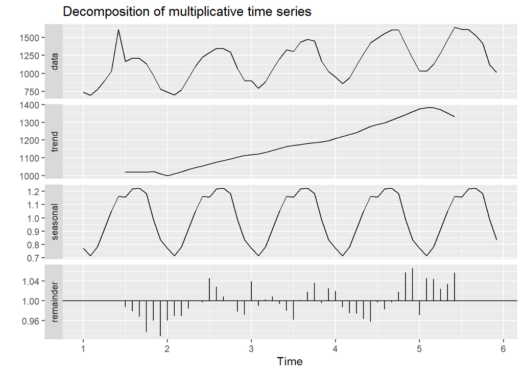

```r
q2e %>% decompose(type = "multiplicative") %>%
  autoplot()
```

- The outlier creates a spike in the data
- It also affected the trend line by creating a dip for the start of year 2
- It did NOT affect the seasonality
- For this, since the spike was so early in the data, it is not clearly shown in the remainder

### 2f.

**Does it make any difference if the outlier is near the end rather than in the middle of the time series?**

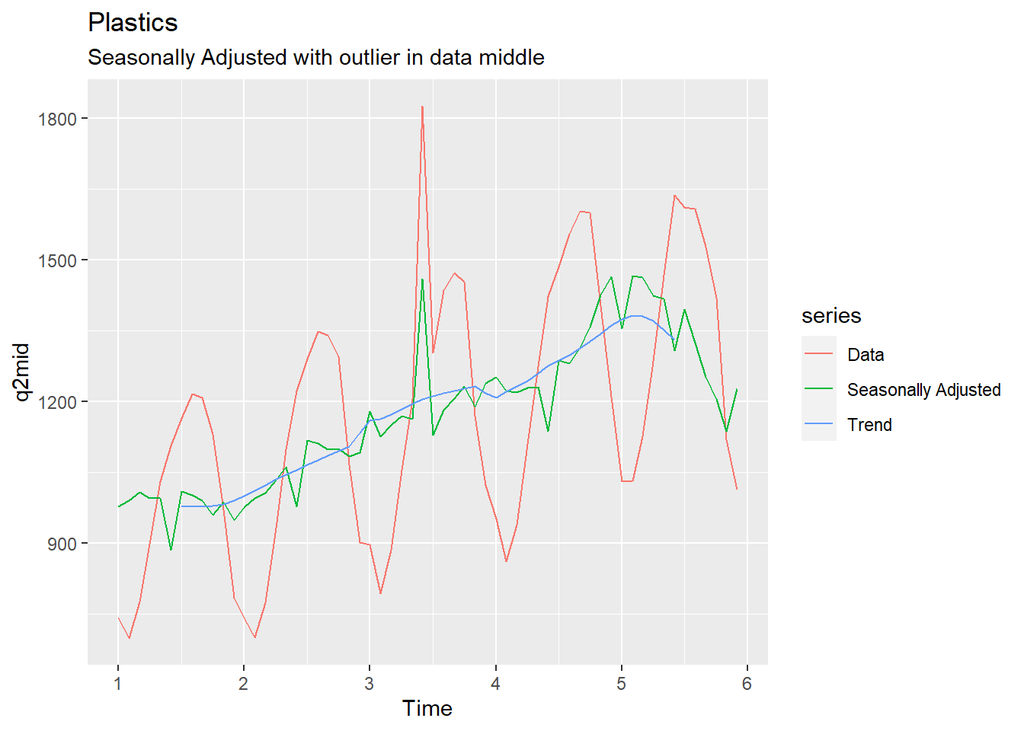

```r
q2mid <- plastics
q2mid[30] <- q2mid[30] + 500

outlier <- q2mid %>%
  decompose(type = "multiplicative")

autoplot(q2mid, series = "Data")+
  autolayer(seasadj(outlier), series = "Seasonally Adjusted")+
  autolayer(trendcycle(outlier), series = "Trend")+
  labs(title = "Plastics", subtitle = "Seasonally Adjusted with outlier in data middle")
```

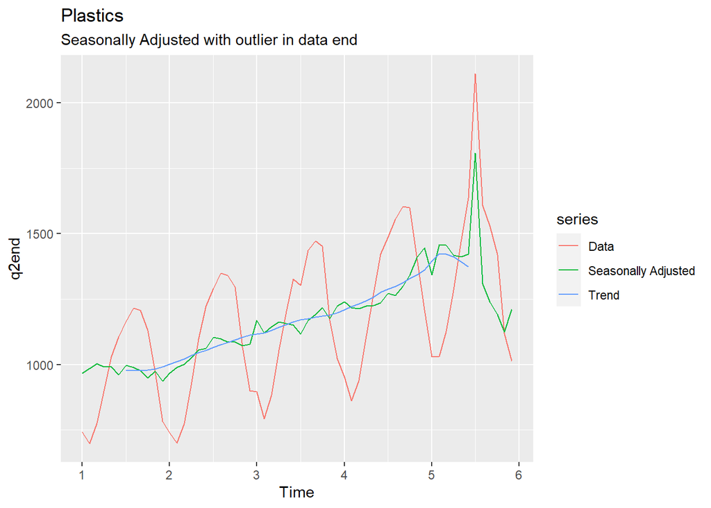

```r
q2end <- plastics
q2end[55] <- q2end[55] + 500

outlier <- q2end %>%
  decompose(type = "multiplicative")

autoplot(q2end, series = "Data")+
  autolayer(seasadj(outlier), series = "Seasonally Adjusted")+
  autolayer(trendcycle(outlier), series = "Trend")+
  labs(title = "Plastics", subtitle = "Seasonally Adjusted with outlier in data end")
```

#### Plastics with NO outlier

```r
plastics %>% decompose(type = "multiplicative")%>%
  autoplot()
```

[output not shown]

#### Plastics with outlier in middle of data

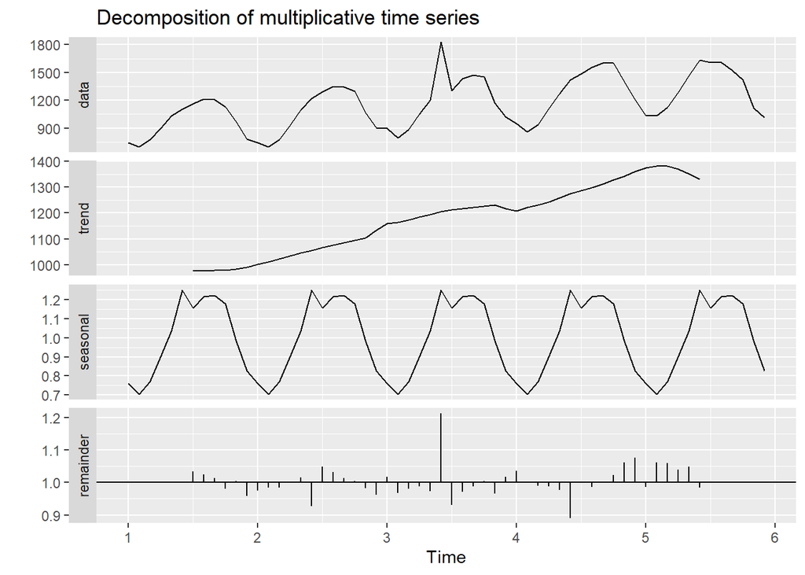

```r
q2mid %>% decompose(type = "multiplicative") %>%
  autoplot()
```

#### Plastics with outlier at the end of the data

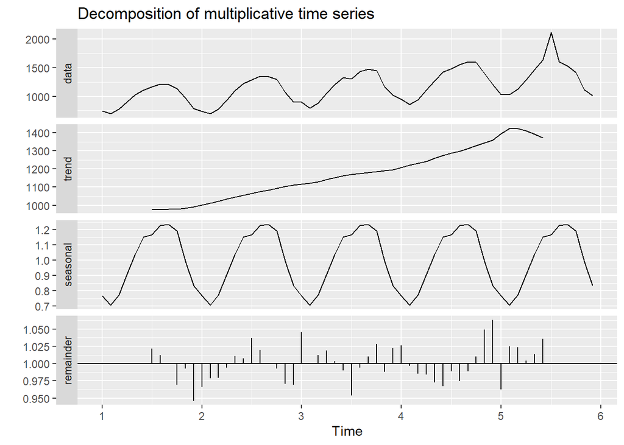

```r
q2end %>% decompose(type = "multiplicative") %>%
  autoplot()
```

- Trend line
  - There is a slight bump in the trend line when the outlier is in the middle
  - When the outlier is at the end the drop off is sharper
- Remainder
  - When the outlier is in the middle there is a clear spike
  - When the outlier is toward the end, the moving average method drops most of the value.
- Seasonal
  - When the spike in in the middle, the seasonal graphs show a distinctive spike at the beginning of the cycle
  - When the spike is at the end, there is very little change

## Question 3:

**Recall your retail time series data (from Exercise 3 in Section 2.10). Decompose the series using X11. Does it reveal any outliers, or unusual features that you had not noticed previously?**

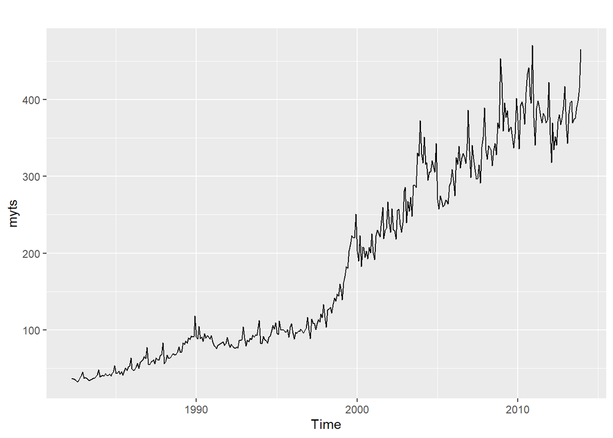

```r
retaildata <- readxl::read_excel("retail.xlsx", skip=1)
myts <- ts(retaildata[,"A3349640L"], frequency=12, start=c(1982,4))

autoplot(myts)
```

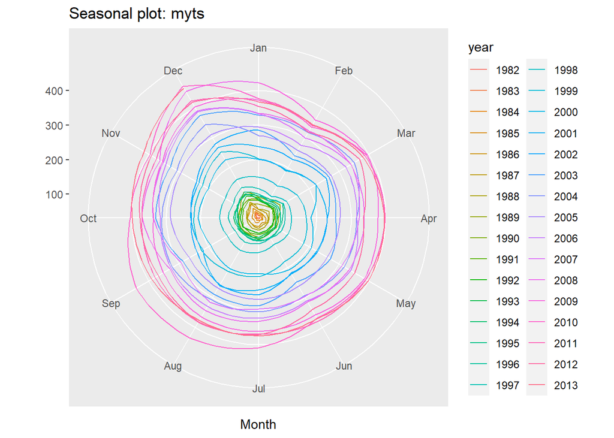

```r
ggseasonplot(myts, polar=TRUE)
```

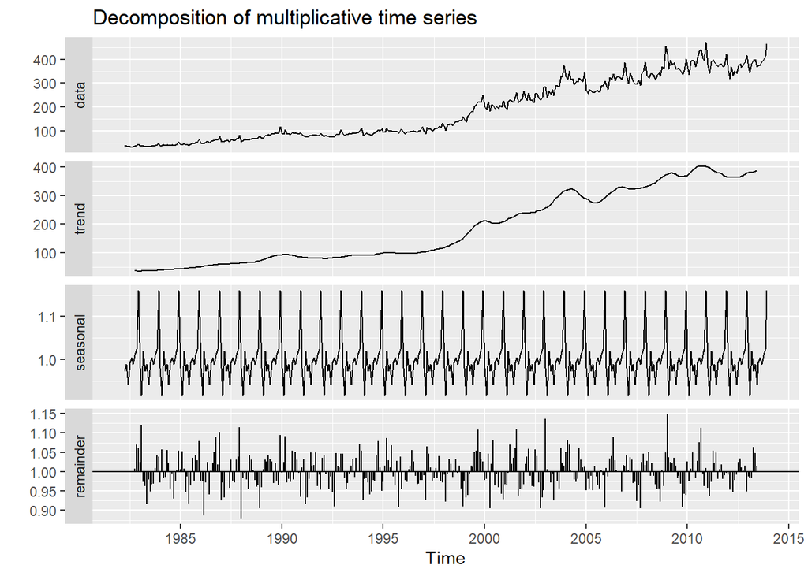

```r
myts %>% decompose(type = "multiplicative") %>%
  autoplot()
```

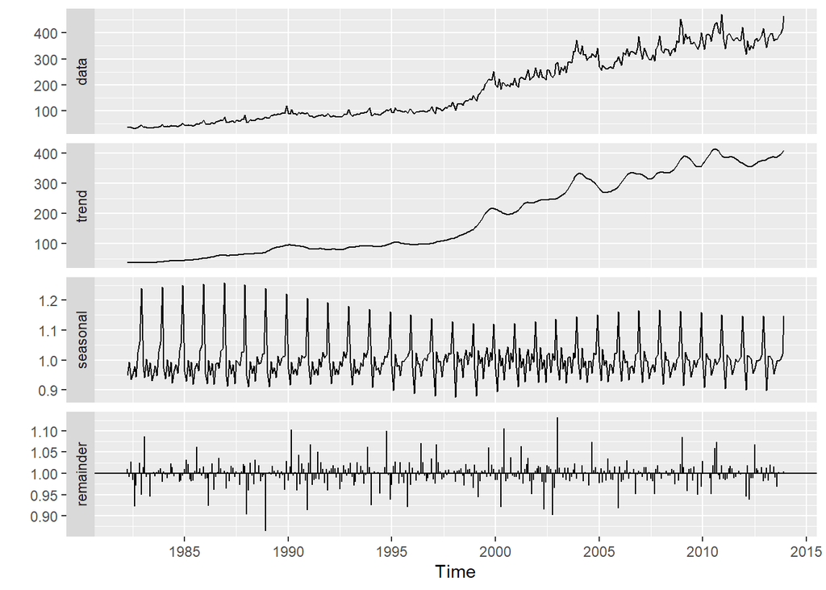

```r
myts_x11 <- seas(myts, x11="")
autoplot(myts_x11)
```

- I’m sure this process “should” show more outliers, however, the column chosen in Assignment 1 was so riddled with outliers already this did not show anything new.